# HSE Hazard Reporting

Mandy Yialeloglou

Health, Safety and Environment

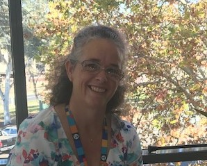

# Introduction

I joined CSIRO in 1989 as a laboartory technician. I have been fortunate to have had many oportunities in both technical and support roles in my 30 years. I moved into the HSE team in 2005 and in my current role as “HSE Specialist - Systems and Analytics” in 2018. I manage our HSE reporting systems and forms, I have a really great working relationship with my IM&T colleagues. I am perfecty happy in the system administration space but I had very few current anaytical skills. I rely heavily on IM&T support for my ‘data wrangling’ and wanted to upskill.

# My Project

This **project** was a ‘proof of concept’ to import, manipulate,interrogate and display data from HSE systems. The long-term view is to be able to bring data from multiple sources to look for potential markers or hotspots to enable effective resourcing and prevenatative programs.

With the incresing demand from the Board, ET, Busines Units and Sites for both regular and *ad hoc* HSE data anaylsis I am working to create a process to accommodate these and be able to answer the *‘what if?’*, *‘why?’*? questions…… eventually.

I started with a confined set of data and chose to look at hazard reported into Lookin2it. Reporting hazards can be viewed as preventative actions, but it’s important to ensure the hazards are addressed and potential risk of injury, illness, operational or envirnmental impact are minimised, so identifying the proportion of hazards with follow up actions was also of interest.

## Preliminary results

Hazards were manipulated to indicate their upper level hazard category, the hazard subgroup within each category and joined to data that had location and business unit information. Some examples of visualising the data is shown below.

**Plots from R**

Example step, display of all hazards reported summarised by hazard category, and showing where the investiagating manager has indicated if follow-up actoins are required.

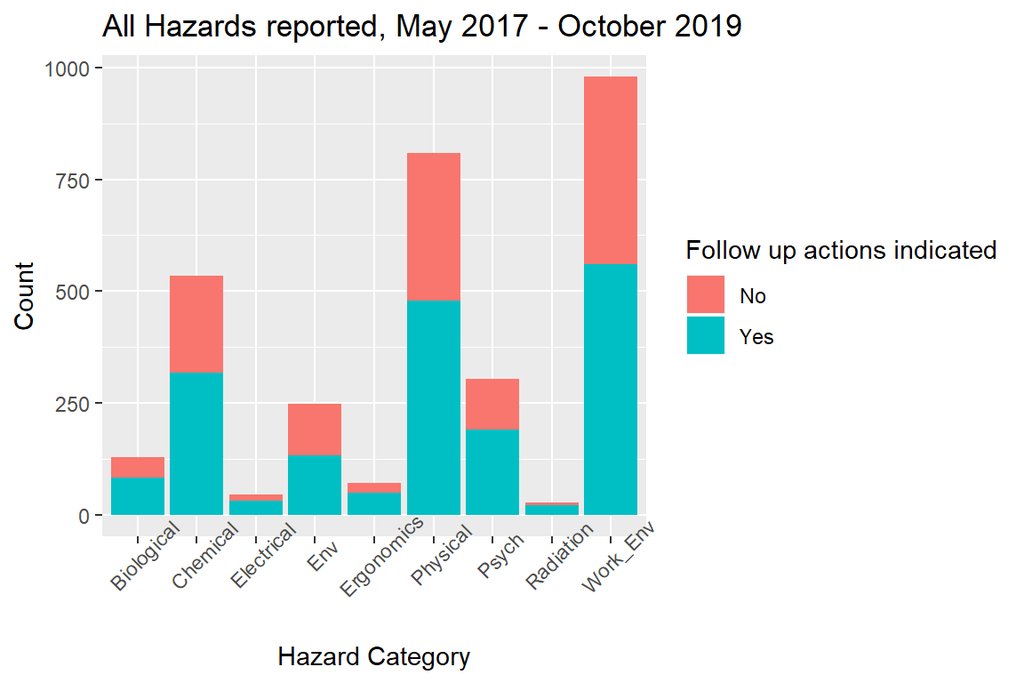

Figure 1: All Hazards reported

Risk profiles for sites potentially be informed byt eh hazards that staff are reporting. This example shows hazards filtered for the Clatyton site

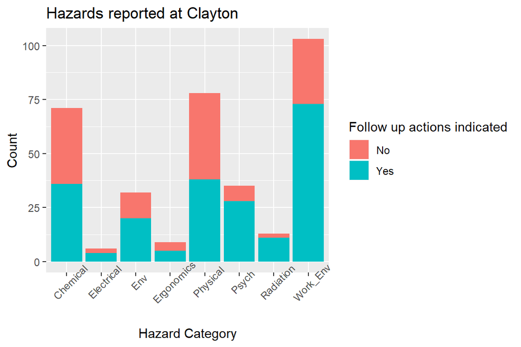

Figure 2: Hazards filtered for Clayton site

Work Environment is a large category so an example of looking at the hazard subgroups that make up this category can further inform here potentail risks lie. This time the results are also displayed by the BU of the person that reported the hazard.

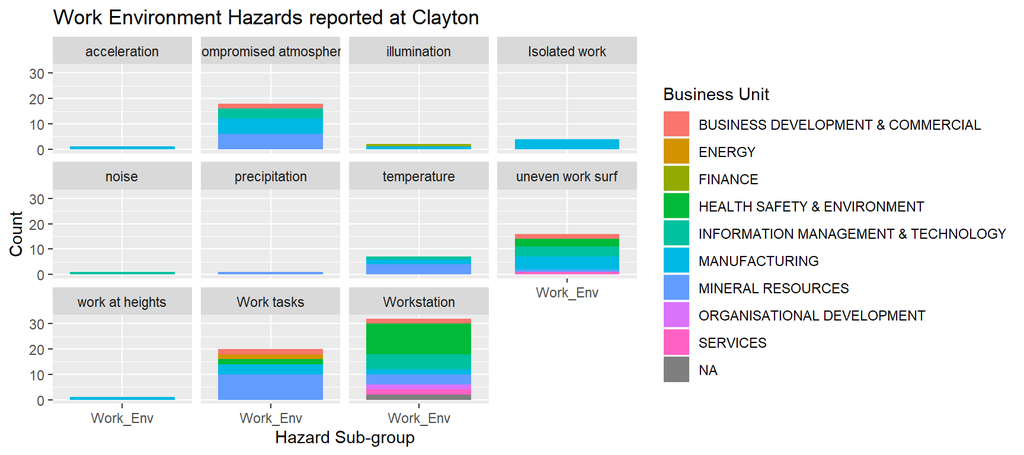

Figure 3: Work Environment Hazards reported at Clayton site

# My Digital Toolbox

I used R and ggplot. I also had some fun with stringr in manipulating categories and sub-categories (and I didn’t have time to drop in images sorry!)

# My time went …

…on taking the principles we’d learned and then trying to write the code to my specific situation.

I feel I grasped the concepts readily and applied them to the examples easily, but I am much better at taking what someone’s done and modifying but less good a ‘starting from scratch’

# Next steps

I’m really excited with the potential R offers and I’m keen to expand my skills and apply in a more holistic way. R offers much greater potential for sharing code for data analysis across HSE as it is a package available to anyone.

# My Data School Experience

Data School has definitely been a highlight of the year. It has been fantastic to be learning a new skill in a really supportive environment. I have really enjoyed the ‘part-time’ format. The trainers and the helpers have a shared passion that is evident and has been transferred!

I can see so much potential in what R can do in the reporting an analytics space so I will be ensuring I block out development time to begin to improve and streamline some of our regular reporting